# RNA-Seq Analysis in Early-Stage Lung Adenocarcinoma

# PCA

#### PCA based on Tumor vs Normal

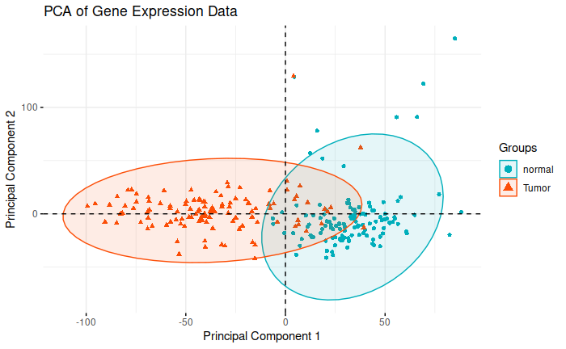

```r
# Extract the 'tissue' column from sample_annotations_ordered to use as a factor
tissue_factor <- factor(sample_annotations_ordered$tissue, levels = c("normal", "tumor"))

# Transpose the data to have samples as rows
transposed_data <- t(significant_expression_data)

# Scale the transposed data
scaled_transposed_data <- scale(transposed_data)

# Perform PCA
pca_res <- PCA(scaled_transposed_data, graph = FALSE)

# Visualize PCA with clusters and tissue type
fviz_pca_ind(pca_res,
             label = "none", # hide labels
             habillage = sample_annotations_ordered$tissue, # color by tissue type
             addEllipses = TRUE, # add confidence ellipses around clusters
             palette = c("#00AFBB", "#FC4E07"), # specify colors for normal and tumor
             title = "PCA of Gene Expression Data",
             xlab = "Principal Component 1",
             ylab = "Principal Component 2"
)
```

#### Identify genes that contribute most to separation

```r
# get loadings
loadings <- pca_res$var$coord

# Identify the genes contributing most to PC1
pc1_loadings <- loadings[, 1] # First principal component loadings
top_pc1_genes <- names(sort(abs(pc1_loadings), decreasing = TRUE))[1:100] # Top 100 genes for PC1
```

# K-means clustering

#### Cluster samples based on gene expression

Determine Optimal Number of Clusters

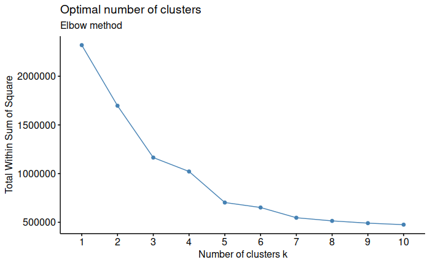

```r
# Scale data
scaled_significant_expression_data <- scale(significant_expression_data)

# Elbow method using fviz_nbclust from the factoextra package
set.seed(123)  # for reproducibility
fviz_nbclust(scaled_significant_expression_data, kmeans, method = "wss") +
  labs(subtitle = "Elbow method")
```

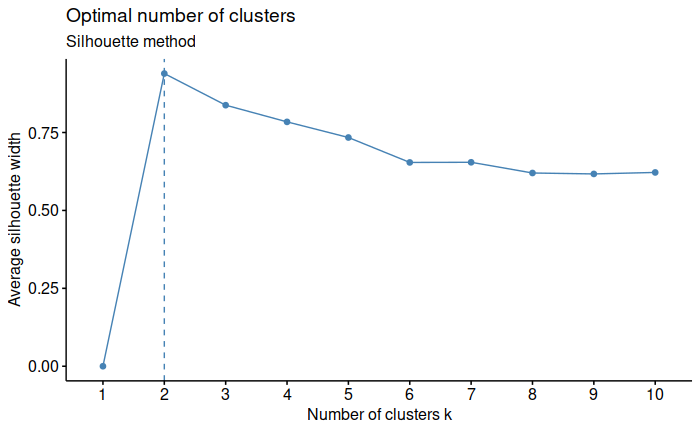

```r
# Silhouette method using fviz_nbclust from the factoextra package
fviz_nbclust(scaled_significant_expression_data, kmeans, method = "silhouette") +
  labs(subtitle = "Silhouette method")
```

```r
# Perform k-means clustering with k = 5
set.seed(123) # Set seed for reproducibility
kmeans_result <- kmeans(scaled_significant_expression_data , centers = 5, nstart = 25)

# Check the within-cluster sum of squares
cat("Total within-cluster sum of squares:", kmeans_result$tot.withinss, "\n")
```

```
Total within-cluster sum of squares: 702910.4
```

```r
# Evaluate the cluster sizes
cat("Cluster sizes:", table(kmeans_result$cluster), "\n")
```

```
Cluster sizes: 984 146 8858 1 11
```

#### Plot Clusters

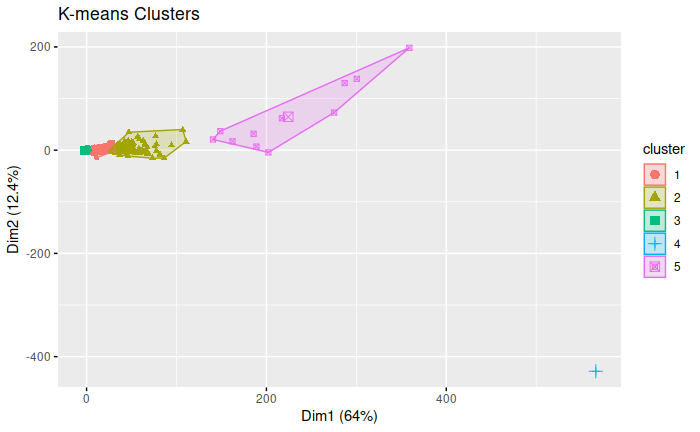

```r
# Visualize the clusters
fviz_cluster(kmeans_result, data = scaled_significant_expression_data, main = "K-means Clusters", geom="point")
```

#### Saving cluster assignments

```r
# Create a data frame with gene names and their corresponding cluster assignments
gene_clusters <- data.frame(Gene = rownames(significant_expression_data),
                            Cluster = kmeans_result$cluster)
```

# Random Forest

#### Prepare data

```r
# Filter out "Unknown" recurrence and only keep "Tumor" samples
filter_indices <- sample_annotations_ordered$tissue == "Tumor" &
                  sample_annotations_ordered$recurrence != "Unknown"

tumor_data <- significant_expression_data[, filter_indices]
recurrence_status <- factor(sample_annotations_ordered$recurrence[filter_indices])

# Verify if the number of columns in tumor_data matches the number of rows in recurrence_status
if (ncol(tumor_data) != length(recurrence_status)) {
    stop("Mismatch in the number of columns in tumor_data and length of recurrence_status")
}

# Convert your data into a data frame where the last column is the target variable
data_for_smote <- as.data.frame(t(tumor_data))  # transpose tumor_data to match samples as rows
data_for_smote$recurrence_status <- recurrence_status

# Check the balance of the dataset
table(data_for_smote$recurrence_status)
```

```
No Progression (>5y)           Recurrence
                  62                   20
```

#### Use SMOTE to correct sample Imbalance

```r
# Apply over-sampling using UBL
smote_data <- SmoteClassif(recurrence_status ~ .,
                           dat = data_for_smote,
                           C.perc = list("No Progression (>5y)" = 1, "Recurrence" = 3),
                           k = 5, repl = FALSE,
                           dist = "Euclidean", p = 2)

# Now check the balance of the new dataset
table(smote_data$recurrence_status)
```

```
No Progression (>5y)           Recurrence
                  62                   60
```

#### Split into Train/Test sets

```r
# Split the balanced data into features and target
tumor_data_smote <- smote_data[, -ncol(smote_data)]
recurrence_status_smote <- smote_data[, ncol(smote_data)]
recurrence_status_smote <- factor(recurrence_status_smote)

# Split the balanced data into training and testing sets
set.seed(123)  # for reproducibility
# Create trainIndex
trainIndex <- createDataPartition(recurrence_status_smote, p = 0.8, list = FALSE, times = 1)
# ubset the rows for the training set
data_train <- tumor_data_smote[trainIndex, ]
# subset the rows for the testing set
data_test <- tumor_data_smote[-trainIndex, ]
# subset the recurrence_status for training and testing
recurrence_train <- recurrence_status_smote[trainIndex]
recurrence_test <- recurrence_status_smote[-trainIndex]
```

#### Train and test model

```r
# Check the structure of the transposed data_train
rf_model <- randomForest(x = data_train, y = recurrence_train,
                         ntree = 200,  # adjust the number of trees
                         keep.forest=TRUE,
                         importance=TRUE,
                         do.trace=10,  # reports OOB error
                         keep.inbag=TRUE)
```

```
ntree      OOB      1      2
   10:  31.63% 32.00% 31.25%
   20:  20.41% 24.00% 16.67%
   30:  13.27% 12.00% 14.58%
   40:  13.27% 14.00% 12.50%
   50:  11.22% 14.00%  8.33%
   60:  12.24% 12.00% 12.50%
   70:  15.31% 14.00% 16.67%
   80:  10.20%  8.00% 12.50%
   90:  14.29% 12.00% 16.67%
  100:  15.31% 16.00% 14.58%
  110:  14.29% 12.00% 16.67%
  120:  14.29% 12.00% 16.67%
  130:  13.27% 12.00% 14.58%
  140:  13.27% 12.00% 14.58%
  150:  11.22%  8.00% 14.58%
  160:  11.22% 10.00% 12.50%
  170:  11.22% 10.00% 12.50%
  180:  10.20%  8.00% 12.50%
  190:  10.20%  8.00% 12.50%
  200:  10.20%  8.00% 12.50%
```

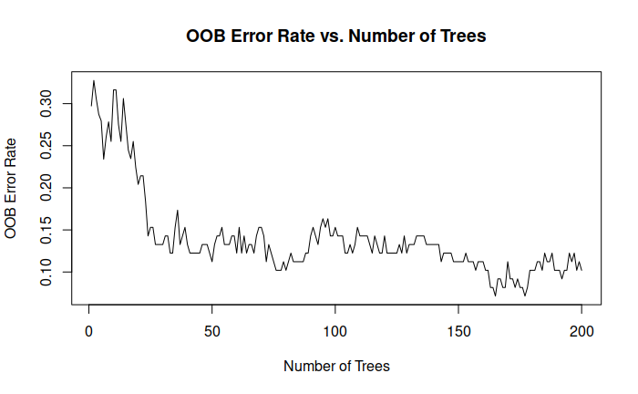

```r
# Plot OOB error with the updated model
oob_error <- rf_model$err.rate[, 1]  # OOB error for classification
ntrees <- 1:length(oob_error)
plot(ntrees, oob_error, type="l", xlab="Number of Trees", ylab="OOB Error Rate", main="OOB Error Rate vs. Number of Trees")
```

```r
NA
NA
NA
```

#### Model Performance

```r
# Assuming that your random forest model is named 'rf_model' and you have 'data_test' and 'recurrence_test' ready
test_pred <- predict(rf_model, newdata = data_test)
conf_matrix <- table(Predicted = test_pred, Actual = recurrence_test)

# Calculate accuracy
accuracy <- sum(diag(conf_matrix)) / sum(conf_matrix)

# Calculate sensitivity (recall) for class 'Recurrence'
sensitivity <- conf_matrix[2, 2] / sum(conf_matrix[2, ])

# Calculate specificity for class 'No Progression'
specificity <- conf_matrix[1, 1] / sum(conf_matrix[1, ])

# Precision (Positive Predictive Value) for class 'Recurrence'
precision <- conf_matrix[2, 2] / sum(conf_matrix[, 2])

# F1 Score for class 'Recurrence'
f1_score <- 2 * (precision * sensitivity) / (precision + sensitivity)

# Compile the metrics into a data frame for nice tabular format
performance_table <- data.frame(
  Accuracy = accuracy,
  Sensitivity = sensitivity,
  Specificity = specificity,
  Precision = precision,
  F1_Score = f1_score
)

# Print the table
print(performance_table)
```

| Accuracy | Sensitivity | Specificity | Precision | F1_Score |
| --- | --- | --- | --- | --- |
| 0.7916667 | 0.8888889 | 0.7333333 | 0.6666667 | 0.7619048 |

#### Get top genes

```r
# Get importance scores
importance_scores <- importance(rf_model, type=1)  # type=1 for MeanDecreaseGini by default

# Convert to a data frame
importance_df <- data.frame(Gene=rownames(importance_scores), Importance=importance_scores[, 1])

# Sort by importance
importance_df_sorted <- importance_df[order(-importance_df$Importance), ]

# Extract the top genes
top_forest_genes <- head(importance_df_sorted, 100)
```

# Selected genes for annotation

```r
# Create a new dataframe with random forest and PCA genes
top_genes_df <- data.frame(
  PCA_Genes = c(top_pc1_genes, rep(NA, max_length - length(top_pc1_genes))),
  Forest_Genes = c(top_forest_genes, rep(NA, max_length - length(top_forest_genes)))
)

# K-means clusters genes
# Subset the data for clusters 2, 4, and 5
cluster_2 <- subset(gene_clusters, Cluster == 2)$Gene
cluster_4 <- subset(gene_clusters, Cluster == 4)$Gene
cluster_5 <- subset(gene_clusters, Cluster == 5)$Gene

# Make all vectors the same length (fill with NA for shorter ones)
cluster_2 <- c(cluster_2, rep(NA, max_length - length(cluster_2)))
cluster_4 <- c(cluster_4, rep(NA, max_length - length(cluster_4)))
cluster_5 <- c(cluster_5, rep(NA, max_length - length(cluster_5)))

# Add new columns to the dataframe
top_genes_df$K_Means_Cluster_2 <- cluster_2
top_genes_df$K_Means_Cluster_4 <- cluster_4
top_genes_df$K_Means_Cluster_5 <- cluster_5

# remove rows with all NAs
top_genes_df <- top_genes_df[rowSums(is.na(top_genes_df)) < ncol(top_genes_df), ]


write.csv(top_genes_df, file = "Data/top_genes_df.csv", row.names = FALSE)
```

#### Inspect Fold Change of selected genes

```r
# Combine all genes from all columns into one vector
all_genes <- unique(c(
  top_genes_df$PCA_Genes,
  top_genes_df$Forest_Genes
))

# Remove NAs and get the unique genes
unique_genes <- unique(na.omit(all_genes))

# Define your colors for different criteria
color_significant <- "#00AFBB"
color_large_change <- "#FC4E07"
color_unique_genes <- "#9B59B6"

# Make a volcano plot with all the genes
with(res, plot(log2FoldChange, -log10(pvalue), pch=20, main="Volcano plot", cex=0.5, xlab="Log2 Fold Change", ylab="-Log10 P-value"))

# Highlight significant genes
with(subset(res, padj < 0.05), points(log2FoldChange, -log10(pvalue), pch=20, col=color_significant, cex=0.5))
```

```r
# Highlight significant genes with large fold changes
with(subset(res, padj < 0.05 & abs(log2FoldChange) > 2), points(log2FoldChange, -log10(pvalue), pch=20, col=color_large_change, cex=0.5))

# Highlight unique genes
unique_genes_in_res <- res[rownames(res) %in% unique_genes, ]
with(unique_genes_in_res, points(log2FoldChange, -log10(pvalue), pch=20, col=color_unique_genes, cex=0.5))
```

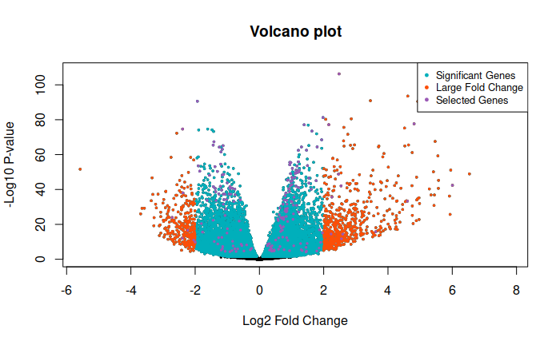

```r
# Add a legend to the plot
legend("topright",
       legend=c("Significant Genes", "Large Fold Change", "Selected Genes"),
       col=c(color_significant, color_large_change, color_unique_genes),
       pch=20,
       cex=0.8)
```

```r
NA
NA
```

# References

1. Dolgalev I, Zhou H, Shenker-Tauris N, Le H, Sakellaropoulos T, Coudray N, Zhu K, Vasudevaraja V, Yeaton A, Goparaju CV, Li Y, Sulaiman I, Tsay JCJ, Meyn P, Mohamed H, Sydney I, Ramaswami S, Narula N, Kulicke R, Davis FP, Stransky N, Smolen GA, Cheng WY, Cai J, Punekar S, Velcheti V, Poirier JT, Neel B, Wong KK, Chiriboga L, Heguy A, Papagiannakopoulos T, Snuderl M, Segal LN, Moreira AL, Pass HI, Tsirigos A. Inflammation in the tumor-adjacent lung as a predictor of clinical outcome in lung adenocarcinoma. bioRxiv. 2022 Nov 10. doi: https://doi.org/10.1101/2022.11.10.516003. Preprint.